# R Notebook

# Introduction

As per Kaggle Website:

Ask a home buyer to describe their dream house, and they probably won’t begin with the height of the basement ceiling or the proximity to an east-west railroad. But this playground competition’s dataset proves that much more influences price negotiations than the number of bedrooms or a white-picket fence.

With 79 explanatory variables describing (almost) every aspect of residential homes in Ames, Iowa, this competition challenges you to predict the final price of each home.

Throughout this analysis we will perform feature engineering on predictors one by one in order to try to form the most accurate prediction for house prices. By the end of this analysis the models of ridge, lasso, and cubist will be performed in order to make the final predictions. Of the three, lasso ultimately performed the best and was chosen as the final submission.

# Libraries

```r
library(ggplot2)
library(plyr,include.only = "revalue")
library(dplyr)
library(caret)
library(gridExtra)
library(e1071) #naive bayes
library(corrplot)
library(Metrics)
library(earth)
library(knitr)
library(gt)
options(scipen=999)
```

# Data

There will be two data sets used in this analysis, the train data set and the test data set. The train data set contains 1460 observations and 81 variables and will be used for the data analysis and model building. The test data set will only used in the end to make the final predictions and contains 1459 rows and 80 variables, with the missing variable being the sale price which we are trying to predict.

Id will not be used in this study until casting final predictions so will be dropped.

```r
train <- read.csv("train.csv",stringsAsFactors = FALSE)

gt(head(train))
```

| Id | MSSubClass | MSZoning | LotFrontage | LotArea | Street | Alley | LotShape | LandContour | Utilities | LotConfig | LandSlope | Neighborhood | Condition1 | Condition2 | BldgType | HouseStyle | OverallQual | OverallCond | YearBuilt | YearRemodAdd | RoofStyle | RoofMatl | Exterior1st | Exterior2nd | MasVnrType | MasVnrArea | ExterQual | ExterCond | Foundation | … |
| --- | --- | --- | --- | --- | --- | --- | --- | --- | --- | --- | --- | --- | --- | --- | --- | --- | --- | --- | --- | --- | --- | --- | --- | --- | --- | --- | --- | --- | --- | --- |
| 1 | 60 | RL | 65 | 8450 | Pave | NA | Reg | Lvl | AllPub | Inside | Gtl | CollgCr | Norm | Norm | 1Fam | 2Story | 7 | 5 | 2003 | 2003 | Gable | CompShg | VinylSd | VinylSd | BrkFace | 196 | Gd | TA | PConc | … |
| 2 | 20 | RL | 80 | 9600 | Pave | NA | Reg | Lvl | AllPub | FR2 | Gtl | Veenker | Feedr | Norm | 1Fam | 1Story | 6 | 8 | 1976 | 1976 | Gable | CompShg | MetalSd | MetalSd | None | 0 | TA | TA | CBlock | … |
| 3 | 60 | RL | 68 | 11250 | Pave | NA | IR1 | Lvl | AllPub | Inside | Gtl | CollgCr | Norm | Norm | 1Fam | 2Story | 7 | 5 | 2001 | 2002 | Gable | CompShg | VinylSd | VinylSd | BrkFace | 162 | Gd | TA | PConc | … |
| 4 | 70 | RL | 60 | 9550 | Pave | NA | IR1 | Lvl | AllPub | Corner | Gtl | Crawfor | Norm | Norm | 1Fam | 2Story | 7 | 5 | 1915 | 1970 | Gable | CompShg | Wd Sdng | Wd Shng | None | 0 | TA | TA | BrkTil | … |
| 5 | 60 | RL | 84 | 14260 | Pave | NA | IR1 | Lvl | AllPub | FR2 | Gtl | NoRidge | Norm | Norm | 1Fam | 2Story | 8 | 5 | 2000 | 2000 | Gable | CompShg | VinylSd | VinylSd | BrkFace | 350 | Gd | TA | PConc | … |
| 6 | 50 | RL | 85 | 14115 | Pave | NA | IR1 | Lvl | AllPub | Inside | Gtl | Mitchel | Norm | Norm | 1Fam | 1.5Fin | 5 | 5 | 1993 | 1995 | Gable | CompShg | VinylSd | VinylSd | None | 0 | TA | TA | Wood | … |

```r
test <- read.csv("test.csv",stringsAsFactors = FALSE)

gt(head(test))
```

| Id | MSSubClass | MSZoning | LotFrontage | LotArea | Street | Alley | LotShape | LandContour | Utilities | LotConfig | LandSlope | Neighborhood | Condition1 | Condition2 | BldgType | HouseStyle | OverallQual | OverallCond | YearBuilt | YearRemodAdd | RoofStyle | RoofMatl | Exterior1st | Exterior2nd | MasVnrType | MasVnrArea | ExterQual | ExterCond | Foundation | … |
| --- | --- | --- | --- | --- | --- | --- | --- | --- | --- | --- | --- | --- | --- | --- | --- | --- | --- | --- | --- | --- | --- | --- | --- | --- | --- | --- | --- | --- | --- | --- |
| 1461 | 20 | RH | 80 | 11622 | Pave | NA | Reg | Lvl | AllPub | Inside | Gtl | NAmes | Feedr | Norm | 1Fam | 1Story | 5 | 6 | 1961 | 1961 | Gable | CompShg | VinylSd | VinylSd | None | 0 | TA | TA | CBlock | … |
| 1462 | 20 | RL | 81 | 14267 | Pave | NA | IR1 | Lvl | AllPub | Corner | Gtl | NAmes | Norm | Norm | 1Fam | 1Story | 6 | 6 | 1958 | 1958 | Hip | CompShg | Wd Sdng | Wd Sdng | BrkFace | 108 | TA | TA | CBlock | … |
| 1463 | 60 | RL | 74 | 13830 | Pave | NA | IR1 | Lvl | AllPub | Inside | Gtl | Gilbert | Norm | Norm | 1Fam | 2Story | 5 | 5 | 1997 | 1998 | Gable | CompShg | VinylSd | VinylSd | None | 0 | TA | TA | PConc | … |
| 1464 | 60 | RL | 78 | 9978 | Pave | NA | IR1 | Lvl | AllPub | Inside | Gtl | Gilbert | Norm | Norm | 1Fam | 2Story | 6 | 6 | 1998 | 1998 | Gable | CompShg | VinylSd | VinylSd | BrkFace | 20 | TA | TA | PConc | … |
| 1465 | 120 | RL | 43 | 5005 | Pave | NA | IR1 | HLS | AllPub | Inside | Gtl | StoneBr | Norm | Norm | TwnhsE | 1Story | 8 | 5 | 1992 | 1992 | Gable | CompShg | HdBoard | HdBoard | None | 0 | Gd | TA | PConc | … |
| 1466 | 60 | RL | 75 | 10000 | Pave | NA | IR1 | Lvl | AllPub | Corner | Gtl | Gilbert | Norm | Norm | 1Fam | 2Story | 6 | 5 | 1993 | 1994 | Gable | CompShg | HdBoard | HdBoard | None | 0 | TA | TA | PConc | … |

# NA Values

There exist many variables with at least one missing value in both the train and test sets.

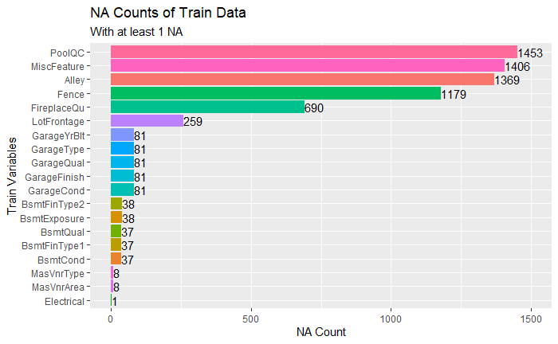

```r
naDF <- data.frame(sapply(train,function(x) sum(is.na(x))))
names(naDF) <- "NA_Count"
naDF$variable <- row.names(naDF)
naDF <- naDF %>%
  filter(NA_Count>0) %>%
  arrange(desc(NA_Count))

ggplot(naDF,aes(x=reorder(variable,NA_Count),y=NA_Count,fill=variable))+
  geom_col()+
  geom_text(aes(label=NA_Count), hjust=0)+
  coord_flip()+
  theme(legend.position = "none")+
  labs(title="NA Counts of Train Data",
       subtitle = "With at least 1 NA")+
  ylab("NA Count")+
  xlab("Train Variables")+
  ylim(0,1500)
```

## Known NA Values

Most of the variables that contain NA values are variables where the NA value is known. For example, the Alley variable replaces the level of “none” with NA and the Basement Quality variable replaces the level of “no basement” with NA.

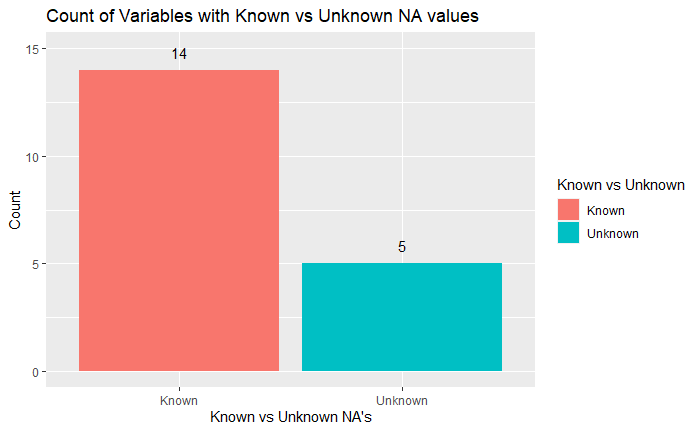

```r
naDF <- naDF %>%
  mutate(knownMissing=ifelse(variable %in% c("Alley","BsmtQual","BsmtCond","BsmtExposure","BsmtFinType1","BsmtFinType2","FireplaceQu","GarageType","GarageFinish","GarageQual","GarageCond","PoolQC","Fence","MiscFeature"),"Known","Unknown"))

ggplot(naDF,aes(x=as.factor(knownMissing),fill=knownMissing))+
  geom_bar()+
  geom_text(stat="count",aes(label=..count..), vjust=-1)+
  xlab("Known vs Unknown NA's")+
  ylab("Count")+
  labs(title="Count of Variables with Known vs Unknown NA values")+
  guides(fill=guide_legend(title="Known vs Unknown"))+
  ylim(0,15)
```

The fourteen variables that have known missing values are Alley, Basement Quality, Basement Condition, Basement Exposure, Basement Finish Type1, Basement Finish Type2, Fire Place Quality, Garage Type, Garage Finish, Garage Quality, Garage Condition, Pool Quality, Fence, and Miscellaneous. The appropriate values will all be added to the train data now to replace the known NA values.

```r
train[is.na(train$Alley),"Alley"] <- "none"

for(name in c("BsmtQual","BsmtCond","BsmtExposure","BsmtFinType1","BsmtFinType2")){
  train[is.na(train[,name]),name] <- "none"
}

train[is.na(train$FireplaceQu),"FireplaceQu"] <- "none"

for(name in c("GarageType","GarageFinish","GarageQual","GarageCond")){
  train[is.na(train[,name]),name] <- "none"
}

train[is.na(train$PoolQC),"PoolQC"] <- "none"

train[is.na(train$Fence),"Fence"] <- "none"

train[is.na(train$MiscFeature),"MiscFeature"] <- "none"
```

The same will be done for the test set.

```r
test[is.na(test$Alley),"Alley"] <- "none"

for(name in c("BsmtQual","BsmtCond","BsmtExposure","BsmtFinType1","BsmtFinType2")){
  test[is.na(test[,name]),name] <- "none"
}

test[is.na(test$FireplaceQu),"FireplaceQu"] <- "none"

for(name in c("GarageType","GarageFinish","GarageQual","GarageCond")){
  test[is.na(test[,name]),name] <- "none"
}

test[is.na(test$PoolQC),"PoolQC"] <- "none"

test[is.na(test$Fence),"Fence"] <- "none"

test[is.na(test$MiscFeature),"MiscFeature"] <- "none"
```

## Unknown NA Values

Only five variables have remaining NA values. These values will be calulated in the feature engineering section.

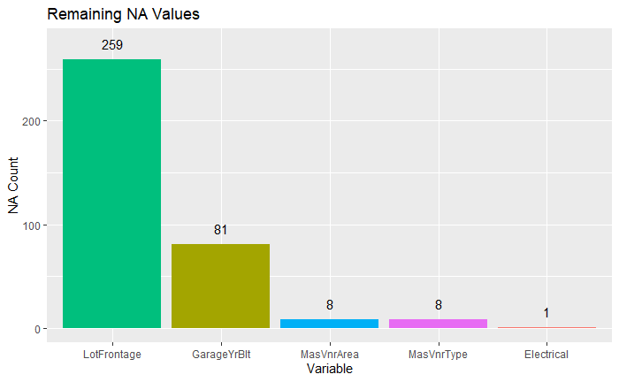

```r
#creating na table
naDF <- data.frame(sapply(train,function(x) sum(is.na(x))))
names(naDF) <- "NA_Count"
naDF$variable <- row.names(naDF)
naDF <- naDF %>%
  select(variable,NA_Count) %>%
  filter(NA_Count>0)

ggplot(naDF,aes(x=variable,y=NA_Count,fill=variable))+
  geom_col(aes(x=reorder(variable,desc(NA_Count))))+
  geom_text(aes(label=NA_Count), vjust=-1)+
  xlab("Variable")+
  ylab("NA Count")+
  labs(title="Remaining NA Values")+
  theme(legend.position = "none")+
  ylim(0,275)
```

```r
NA
NA
```

# Correlation Plots

There exists strong correlations with some of the predictors with correlation values above .8.

```r
numericPredictors <- train[complete.cases(train),c(-1,-81)] %>% select_if(is.numeric) #1 = ID 81=SalesPrice

correlations <- as.data.frame(as.table(cor(numericPredictors)))

correlations <- correlations %>% filter(Freq!=1) %>% arrange(desc(Freq)) %>% rename(correlation=Freq)

gt(correlations[seq(1,nrow(correlations),by=2),] %>% head(10))
```

| Var1 | Var2 | correlation |
| --- | --- | --- |
| GarageArea | GarageCars | 0.8396258 |
| X1stFlrSF | TotalBsmtSF | 0.8358336 |
| TotRmsAbvGrd | GrLivArea | 0.8244260 |
| GarageYrBlt | YearBuilt | 0.8233292 |
| GrLivArea | X2ndFlrSF | 0.6885976 |
| BsmtFullBath | BsmtFinSF1 | 0.6514960 |
| TotRmsAbvGrd | BedroomAbvGr | 0.6502724 |
| GarageYrBlt | YearRemodAdd | 0.6454552 |
| YearRemodAdd | YearBuilt | 0.6228006 |
| TotRmsAbvGrd | X2ndFlrSF | 0.6177579 |

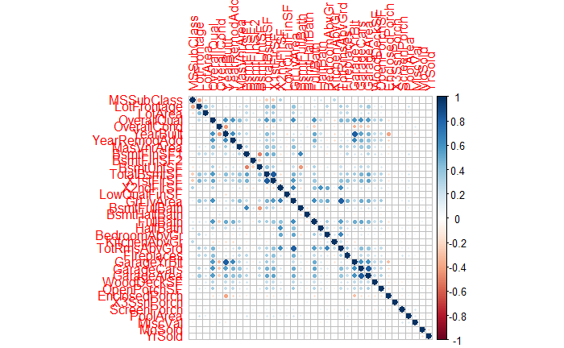

```r
corrplot(cor(numericPredictors))
```

One of the predictors from each pair of correlated predictors with a correlation value above .8 will be dropped. Since garage year built has eighty-one NA values it will be dropped from that pair. The choice of which one to drop from the remaining three pairs will be based off which predictor has a lower correlation with the dependent variable of Sales Price. The predictors that will be dropped are total rooms above ground, first floor sf, and garage area.

```r
numericPredictors <- cbind(SalePrice=train[complete.cases(train),"SalePrice"],numericPredictors)

correlationWithSalePrice <- as.data.frame(sapply(numericPredictors,function(x) cor(x,numericPredictors$SalePrice,use="complete.obs")))

names(correlationWithSalePrice) <- "correlation"
correlationWithSalePrice$predictor <- row.names(correlationWithSalePrice)

correlationWithSalePrice %>% filter(predictor %in% c("GarageArea","GarageCars","X1stFlrSF","TotalBsmtSF","TotRmsAbvGrd","GrLivArea")) %>% arrange(desc(correlation))
```

|  | correlation | predictor |
| --- | --- | --- |
| GrLivArea | 0.7051392 | GrLivArea |
| GarageCars | 0.6470931 | GarageCars |
| GarageArea | 0.6193185 | GarageArea |
| TotalBsmtSF | 0.6159898 | TotalBsmtSF |
| X1stFlrSF | 0.6080921 | X1stFlrSF |
| TotRmsAbvGrd | 0.5471478 | TotRmsAbvGrd |

```r
categoricalPredictors <- train %>% select_if(is.character)
chisq.test(table(categoricalPredictors$MSZoning,categoricalPredictors$Street))$p.value

i <- 1
for(i in i:ncol(categoricalPredictors)){
  j=i+1
  if(j!=ncol(categoricalPredictors)+1){
  for(j in j:ncol(categoricalPredictors)){

    if(chisq.test(table(categoricalPredictors[,i],categoricalPredictors[,j]))$p.value<.05){

    pValue=round(chisq.test(table(categoricalPredictors[,i],categoricalPredictors[,j]))$p.value,5)

    print(paste(names(categoricalPredictors)[i],names(categoricalPredictors)[j],pValue))
    }
    }
  }
}
```

[output not shown]

# Data Analysis

## ggplot Custom Functions

ggplot function for continuous data:

```r
#train with complete observations only

numericggplot <- function(variable){
  histo <- ggplot(train,aes(x=train[,variable]))+
    geom_histogram()+
    xlab(variable)+
    theme(axis.text=element_text(size=14),
          axis.title=element_text(size=14,face="bold"))+
    labs(title=variable)


  scattero <- ggplot(train,aes(x=train[,variable],y=SalePrice))+
    geom_point()+
    geom_smooth(method = "lm", se=FALSE, color="black")+
    xlab(variable)+
    ylab("SalePrice")+
    theme(axis.text=element_text(size=14),
          axis.title=element_text(size=14,face="bold"))+
    labs(title=variable)

grid.arrange(histo,scattero,ncol=2)
}
```

ggplot function for discrete data:

```r
discreteggplot <- function(name){
    discretePlot <- ggplot(train,aes(x=as.factor(train[,name])))+
    geom_bar()+xlab(name)

discreteBox <- ggplot(train,aes(x=as.factor(train[,name]),y=SalePrice))+
    geom_boxplot()+xlab(name)

grid.arrange(discretePlot,discreteBox,ncol=2)
}
```

## Dependent Variable

The dependent variable we are trying to predict is SalePrice. **SalePrice** represents the prices of houses in Ames, Iowa. It exists in the train data set, but not in the test data set. It is skewed to the right with some very high trailing values.

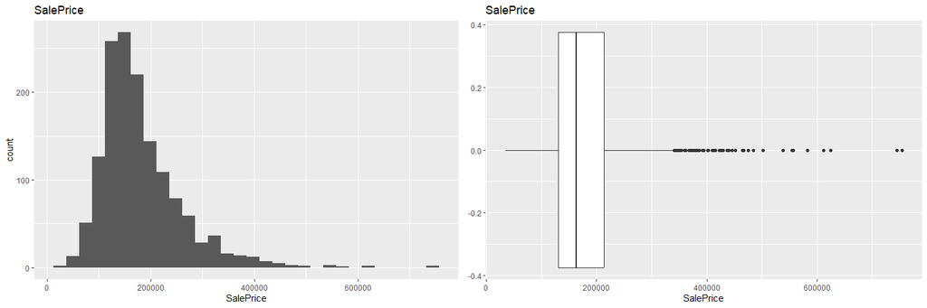

```r
salePriceHisto <- ggplot(train,aes(x=SalePrice))+
  geom_histogram()+
  labs(title="SalePrice")

salePriceBox <- ggplot(train,aes(x=SalePrice))+
  geom_boxplot()+
  labs(title="SalePrice")

grid.arrange(salePriceHisto,salePriceBox,ncol=2)
```

By applying the log transformation the sale price becomes normally distributed.

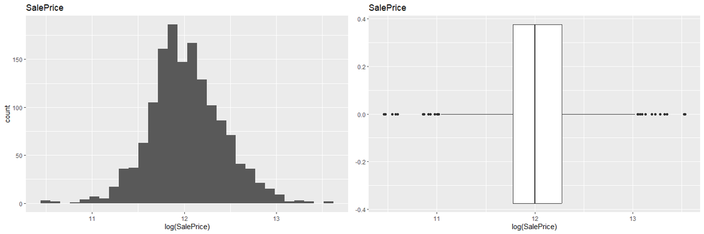

```r
salePriceHistoLog <- ggplot(train,aes(x=log(SalePrice)))+
  geom_histogram()+
  labs(title="SalePrice")+
  xlab("log(SalePrice)")

salePriceBoxLog <- ggplot(train,aes(x=log(SalePrice)))+
  geom_boxplot()+
  labs(title="SalePrice")+
  xlab("log(SalePrice)")

grid.arrange(salePriceHistoLog,salePriceBoxLog,ncol=2)
```

## Numeric Predictors

For numeric variables in general if it is an ordered predictor we will make it an integer and if not we will make it a double. This will make the pre-processing (scaling, centering…) much easier.

### Lot Frontage and Area

**LotFrontage:** Linear feet of street connected to a property. There appears to be two outliers with lot frontage above 300 including observations 935 and 1299. Due to the high number of missing values more sophisticated methods of imputation will have to be used.

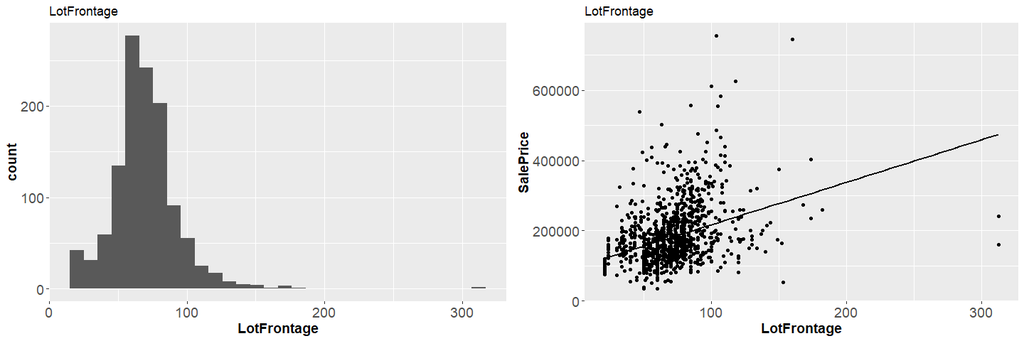

```r
numericggplot("LotFrontage")
```

```r
kable(train %>% filter(LotFrontage>300))
```

| Id | MSSubClass | MSZoning | LotFrontage | LotArea | Street | Alley | LotShape | LandContour | Utilities | LotConfig | LandSlope | Neighborhood | Condition1 | Condition2 | BldgType | HouseStyle | OverallQual | OverallCond | YearBuilt | YearRemodAdd | RoofStyle | RoofMatl | Exterior1st | Exterior2nd | MasVnrType | MasVnrArea | ExterQual | ExterCond | Foundation | … |
| --- | --- | --- | --- | --- | --- | --- | --- | --- | --- | --- | --- | --- | --- | --- | --- | --- | --- | --- | --- | --- | --- | --- | --- | --- | --- | --- | --- | --- | --- | --- |
| 935 | 20 | RL | 313 | 27650 | Pave | none | IR2 | HLS | AllPub | Inside | Mod | NAmes | PosA | Norm | 1Fam | 1Story | 7 | 7 | 1960 | 2007 | Flat | Tar&Grv | Wd Sdng | Wd Sdng | None | 0 | TA | TA | CBlock | … |
| 1299 | 60 | RL | 313 | 63887 | Pave | none | IR3 | Bnk | AllPub | Corner | Gtl | Edwards | Feedr | Norm | 1Fam | 2Story | 10 | 5 | 2008 | 2008 | Hip | ClyTile | Stucco | Stucco | Stone | 796 | Ex | TA | PConc | … |

**LotArea:** Lot size in square feet. Contains only four values above 100,000 including observations 250, 314, 336, and 707.

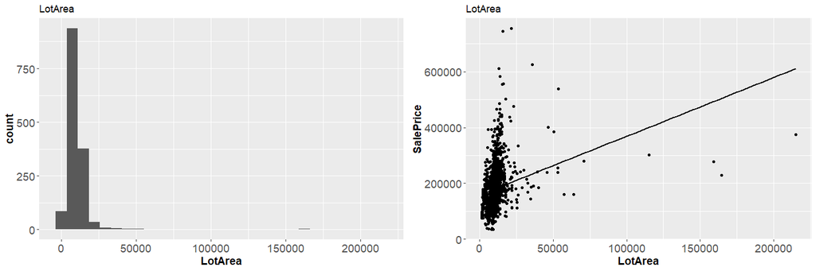

```r
numericggplot("LotArea")
```

```r
kable(train[train$LotArea>100000,])
```

|  | Id | MSSubClass | MSZoning | LotFrontage | LotArea | Street | Alley | LotShape | LandContour | Utilities | LotConfig | LandSlope | Neighborhood | Condition1 | Condition2 | BldgType | HouseStyle | OverallQual | OverallCond | YearBuilt | YearRemodAdd | RoofStyle | RoofMatl | Exterior1st | Exterior2nd | MasVnrType | MasVnrArea | ExterQual | ExterCond | … |
| --- | --- | --- | --- | --- | --- | --- | --- | --- | --- | --- | --- | --- | --- | --- | --- | --- | --- | --- | --- | --- | --- | --- | --- | --- | --- | --- | --- | --- | --- | --- |
| 250 | 250 | 50 | RL | NA | 159000 | Pave | none | IR2 | Low | AllPub | CulDSac | Sev | ClearCr | Norm | Norm | 1Fam | 1.5Fin | 6 | 7 | 1958 | 2006 | Gable | CompShg | Wd Sdng | HdBoard | BrkCmn | 472 | Gd | TA | … |
| 314 | 314 | 20 | RL | 150 | 215245 | Pave | none | IR3 | Low | AllPub | Inside | Sev | Timber | Norm | Norm | 1Fam | 1Story | 7 | 5 | 1965 | 1965 | Hip | CompShg | BrkFace | BrkFace | None | 0 | TA | TA | … |
| 336 | 336 | 190 | RL | NA | 164660 | Grvl | none | IR1 | HLS | AllPub | Corner | Sev | Timber | Norm | Norm | 2fmCon | 1.5Fin | 5 | 6 | 1965 | 1965 | Gable | CompShg | Plywood | Plywood | None | 0 | TA | TA | … |
| 707 | 707 | 20 | RL | NA | 115149 | Pave | none | IR2 | Low | AllPub | CulDSac | Sev | ClearCr | Norm | Norm | 1Fam | 1Story | 7 | 5 | 1971 | 2002 | Gable | CompShg | Plywood | Plywood | Stone | 351 | TA | TA | … |

$\textbf{Pick the next tab in order to see other variables.}$

### Misc Value

**MiscVal:** Value of miscellaneous features. Most have a value of zero inferring no miscellaneous feature. Given that the value is not zero, the average miscellaneous value is 1221.

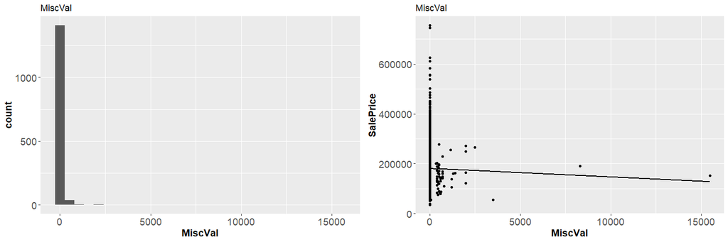

```r
numericggplot("MiscVal")
```

```r
miscValTable <- as.data.frame(table(train$MiscVal))
names(miscValTable) <- c("value","frequency")
kable(miscValTable)
```

| value | frequency |
| --- | --- |
| 0 | 1408 |
| 54 | 1 |
| 350 | 1 |
| 400 | 11 |
| 450 | 4 |
| 480 | 2 |
| 500 | 8 |
| 560 | 1 |
| 600 | 4 |
| 620 | 1 |
| 700 | 5 |
| 800 | 1 |
| 1150 | 1 |
| 1200 | 2 |
| 1300 | 1 |
| 1400 | 1 |
| 2000 | 4 |
| 2500 | 1 |
| 3500 | 1 |
| 8300 | 1 |
| 15500 | 1 |

```r
#average price of misc. value given not 0
round(mean(train[!is.na(train$MiscVal) & train$MiscVal!=0,"MiscVal"]),1)
```

```
[1] 1221
```

$\textbf{Pick the next tab in order to see other variables.}$

### Year Built, Year Remodeled, Garage Year Built

**YearBuilt:** Original construction date. The newer the house, the higher the house prices are. However, there are a couple houses built before 1900 that are very expensize. Investigating we can see that all four of these houses had a recent remodel. A predictor will be added for houses that have a remodel year that is not equal to the year the house was built.

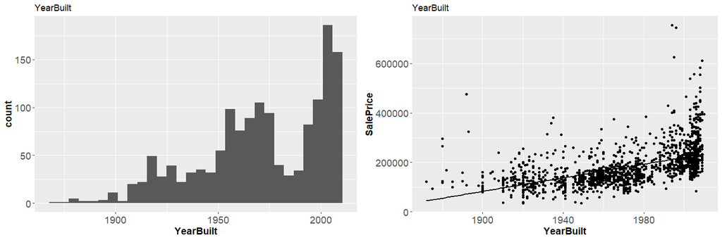

```r
numericggplot("YearBuilt")
```

```r
kable(train[train$SalePrice>200000 & train$YearBuilt<1900 & !is.na(train$SalePrice),c("YearBuilt","YearRemodAdd","SalePrice")])
```

|  | YearBuilt | YearRemodAdd | SalePrice |
| --- | --- | --- | --- |
| 186 | 1892 | 1993 | 475000 |
| 305 | 1880 | 2002 | 295000 |
| 584 | 1893 | 2000 | 325000 |
| 748 | 1880 | 2003 | 265979 |

**YearRemodAdd:** Remodel date (same as construction date if no remodeling or additions). Fifty-two percent of houses did not have a remodel.

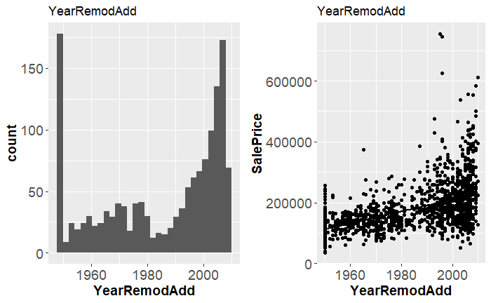

```r
numericggplot("YearRemodAdd")
```

```r
print(paste(round(sum(train$YearRemodAdd==train$YearBuilt)/nrow(train)*100,0),"% of houses did not have a remodel."))
```

```
[1] "52 % of houses did not have a remodel."
```

**GarageYrBlt:** Year garage was built. 75% of the time the garage was built when the house was built. There will be an added feature later on to depict whether or not the garage was added after the house was built. All eighty-one of the NA values in garage year built are due to the fact that the house does not have a garage.

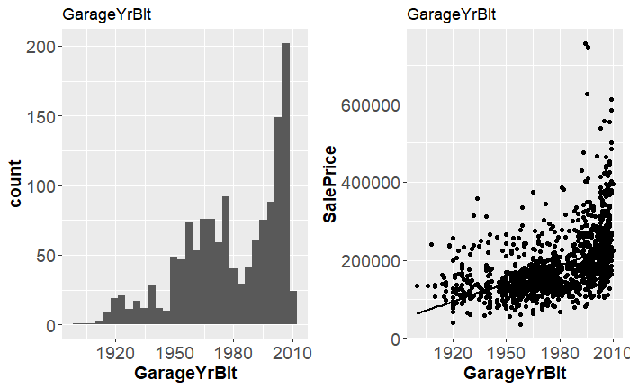

```r
numericggplot("GarageYrBlt")
```

```r
#percentage of time garage was built when house was built
round(sum(train$GarageYrBlt==train$YearBuilt,na.rm=TRUE)/nrow(train),2)
```

```
[1] 0.75
```

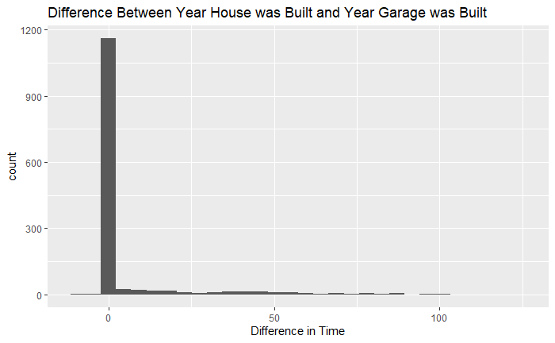

```r
#comparing garage year built with house year built
ggplot(train,aes(x=GarageYrBlt-YearBuilt))+
  geom_histogram()+
  xlab("Difference in Time")+
  labs(title="Difference Between Year House was Built and Year Garage was Built")
```

```r
table(train[is.na(train$GarageYrBlt),"GarageYrBlt"],train[is.na(train$GarageYrBlt),"GarageFinish"],exclude=FALSE)
```

```
       none
  <NA>   81
```

$\textbf{Pick the next tab in order to see other variables.}$